# 02 - Data Preprocessing

Biostatistics 735 — Machine Learning in Public Health

Author

Alexander McLain

Published

August 20, 2026

# 1 Overview

Raw data is almost never ready to feed into a model. Before you fit anything — a linear model, a penalized regression, a tree — you need to decide how to handle missing values, unusual observations, imbalanced outcomes, and variables that are on the wrong scale or in the wrong format. These decisions are not optional housekeeping; they change your results, and doing them incorrectly is one of the most common sources of invalid machine learning results.

By the end of this document you will be able to:

- Diagnose and handle missing data
- Detect and reason about outliers
- Recognize class imbalance and know the basic strategies for addressing it
- Engineer and encode features so they are usable by a wide range of models
- Split data into training and test sets using the `rsample` package, and explain why this has to happen before (or alongside) the steps above

This document sits between **01 - Introduction to R** and **03 - Cross Validation**. Everything here uses tools from document 1 (`dplyr`, `ggplot2`, factors). The train/test split introduced at the end is the exact tool used at the start of document 3 — read that section carefully, because we will not re-explain `initial_split()` when it reappears there.

# 2 Packages

```r
install.packages(c("naniar", "rsample"))
```

| Package | Purpose |
| --- | --- |
| `naniar` | Summarizing and visualizing missing data |
| `rsample` | Creating train/test splits and (later) cross-validation folds |

We continue to use the cleaned `framingham` data frame from document 1 (binary/categorical variables already converted to factors).

# 3 Why Preprocessing Matters

Classical statistical models (like `lm()`) are often forgiving: they will run with missing data silently dropped, with outliers pulling a coefficient, with a rare outcome class, and give you an answer — just possibly a misleading one. Many machine learning methods are less forgiving in a different way: some simply **fail** on missing data (`glmnet`, most tree ensembles via certain implementations), some are **sensitive to scale** (penalized regression, k-nearest neighbors, neural networks), and some are **sensitive to class imbalance** in ways that are easy to miss (a model can achieve 98% accuracy by always predicting “no disease” if disease is rare).

**Important**

Preprocessing decisions should be made **before** you look at how they affect model performance on your test set. Deciding how to impute missing data, or which outliers to remove, based on what improves your test-set score is itself a form of data leakage — a topic covered in depth in document 3.

# 4 Missing Data

## 4.1 Diagnosing Missingness

Start by quantifying how much is missing, and where.

```r
framingham |>
  summarize(across(everything(), ~ mean(is.na(.)) * 100)) |>
  pivot_longer(everything(), names_to = "variable", values_to = "pct_missing") |>
  filter(pct_missing > 0) |>
  arrange(desc(pct_missing))
```

```
# A tibble: 7 × 2
  variable   pct_missing
  <chr>            <dbl>
1 glucose         9.15
2 education       2.48
3 BPMeds          1.25
4 totChol         1.18
5 cigsPerDay      0.684
6 BMI             0.448
7 heartRate       0.0236
```

`naniar` gives a quick visual of the same information:

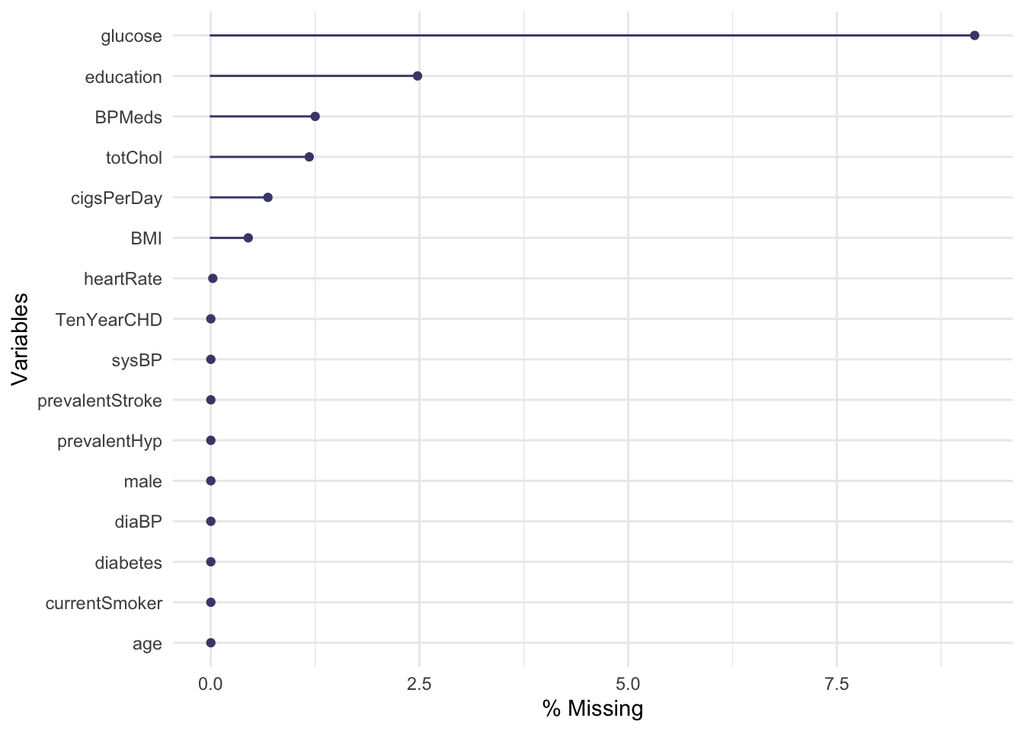

```r
gg_miss_var(framingham, show_pct = TRUE)
```

## 4.2 Missingness Mechanisms (Briefly)

You do not need the full technical machinery to make reasonable decisions, but it helps to know the vocabulary:

| Mechanism | Meaning | Example |
| --- | --- | --- |
| **MCAR** — Missing Completely at Random | Missingness is unrelated to any variable, observed or not | A lab sample is dropped due to a shipping error |
| **MAR** — Missing at Random | Missingness depends on *observed* variables | Older participants are less likely to complete a cognitive test |
| **MNAR** — Missing Not at Random | Missingness depends on the *unobserved* value itself | Participants with very high blood pressure skip the BP reading |

**Note**

Most simple imputation methods (mean/median imputation, complete-case analysis) assume something close to MCAR. If missingness looks related to other variables in your data (check this with `naniar::gg_miss_fct()` or by comparing summary statistics between complete and incomplete cases), simple methods can introduce bias. This course does not require formal MAR/MNAR modeling — just be aware of the assumption you are making.

## 4.3 Handling Missing Data

**Option 1: Complete-case analysis (listwise deletion).** Drop any row with a missing value in a variable you plan to use.

```r
framingham_cc <- framingham |>
  drop_na(totChol, BMI, heartRate, glucose)

nrow(framingham); nrow(framingham_cc)
```

```
[1] 4240
```

```
[1] 3827
```

This is simple and always valid under MCAR, but it throws away data — often a lot of it, if missingness is spread across many variables — and can bias results if missingness is not MCAR.

**Option 2: Simple imputation.** Replace missing values with a summary statistic, most commonly the mean or median for numeric variables and the mode for categorical variables.

```r
framingham_imp <- framingham |>
  mutate(
    glucose  = if_else(is.na(glucose),  median(glucose,  na.rm = TRUE), glucose),
    heartRate = if_else(is.na(heartRate), median(heartRate, na.rm = TRUE), heartRate)
  )
```

**Important**

**The mean/median you impute with must come from the training data only.** If you compute it on the full dataset (train + test) before splitting, or on the test set itself, information from the test set leaks into your training process. The correct order is: split first, then compute imputation values on `train`, then apply those same values to both `train` and `test`. We will split the data at the end of this document, and document 3 shows exactly this pattern for centering and scaling.

**Option 3: Model-based imputation.** Methods like k-nearest-neighbor imputation or multiple imputation (`mice`, `VIM` packages) predict each missing value from other variables rather than using a single summary statistic. These are more accurate but add complexity and are beyond the scope of this course; mean/median imputation or complete-case analysis will be sufficient for our homework and projects unless stated otherwise.

# 5 Outliers

## 5.1 Detecting Outliers

Two common rules of thumb for a single numeric variable:

- **IQR rule:** flag values below $Q_1 - 1.5 \times \text{IQR}$ or above $Q_3 + 1.5 \times \text{IQR}$ (this is what `geom_boxplot()` flags as points).
- **Z-score rule:** flag values more than 3 (or so) standard deviations from the mean.

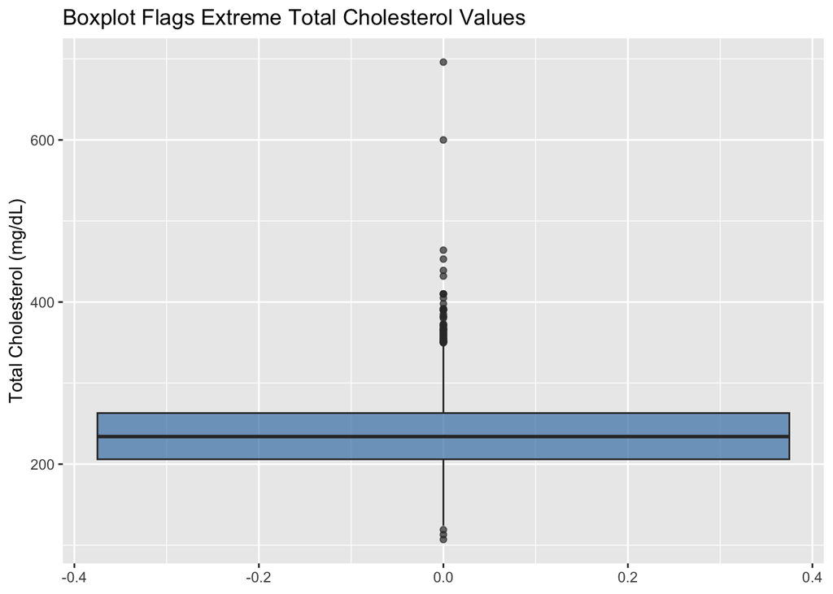

```r
ggplot(framingham, aes(y = totChol)) +
  geom_boxplot(fill = "steelblue", alpha = 0.7) +
  labs(y = "Total Cholesterol (mg/dL)",
       title = "Boxplot Flags Extreme Total Cholesterol Values")
```

```r
framingham |>
  mutate(
    q1 = quantile(totChol, 0.25, na.rm = TRUE),
    q3 = quantile(totChol, 0.75, na.rm = TRUE),
    iqr = q3 - q1,
    outlier_iqr = totChol < (q1 - 1.5 * iqr) | totChol > (q3 + 1.5 * iqr)
  ) |>
  count(outlier_iqr)
```

```
# A tibble: 3 × 2
  outlier_iqr     n
  <lgl>       <int>
1 FALSE        4134
2 TRUE           56
3 NA             50
```

## 5.2 Deciding What to Do

Flagging an outlier is not the same as knowing what to do with it. Ask:

- **Is it a data-entry error?** (e.g., height of 7 feet, age of 200) — fix or remove it.
- **Is it a real, extreme observation?** (e.g., a genuinely very high cholesterol reading) — this may be exactly the kind of patient your model needs to learn about. Removing it can hurt generalizability.
- **Is it distorting a distance- or scale-sensitive model** (k-NN, penalized regression, neural networks) without being an error? Consider a transformation (e.g., `log()`) or **winsorizing** (capping extreme values at a percentile) rather than deleting the observation.

```r
framingham |>
  mutate(
    totChol_capped = pmin(pmax(totChol, quantile(totChol, 0.01, na.rm = TRUE)),
                                quantile(totChol, 0.99, na.rm = TRUE))
  ) |>
  select(totChol, totChol_capped) |>
  summary()
```

```
    totChol      totChol_capped
 Min.   :107.0   Min.   :153.0
 1st Qu.:206.0   1st Qu.:206.0
 Median :234.0   Median :234.0
 Mean   :236.7   Mean   :236.4
 3rd Qu.:263.0   3rd Qu.:263.0
 Max.   :696.0   Max.   :354.1
 NA's   :50      NA's   :50
```

**Tip**

As with missing data, if you cap or remove outliers using percentiles computed on the full dataset, you again risk leaking test information into your training process. Compute the thresholds on `train` only.

# 6 Class Imbalance

`TenYearCHD` — whether a participant developed coronary heart disease within 10 years — is the outcome we will use in several classification examples this semester. It is **imbalanced**: most participants did not develop CHD.

```r
framingham |>
  count(TenYearCHD) |>
  mutate(pct = n / sum(n) * 100)
```

```
# A tibble: 2 × 3
  TenYearCHD     n   pct
  <fct>      <int> <dbl>
1 No          3596  84.8
2 Yes          644  15.2
```

## 6.1 Why This Is a Problem

A classifier that always predicts “No” will be correct roughly 85% of the time on this data — a high accuracy that tells you nothing useful. Imbalance affects both **model fitting** (many algorithms implicitly optimize overall accuracy and will lean toward the majority class) and **model evaluation** (accuracy is the wrong metric to trust; sensitivity, specificity, and precision-recall become important — covered later in the course).

## 6.2 Basic Strategies

**Downsampling** the majority class:

```r
set.seed(1)
min_n <- framingham |> count(TenYearCHD) |> pull(n) |> min()

framingham_down <- framingham |>
  group_by(TenYearCHD) |>
  slice_sample(n = min_n) |>
  ungroup()

framingham_down |> count(TenYearCHD)
```

```
# A tibble: 2 × 2
  TenYearCHD     n
  <fct>      <int>
1 No           644
2 Yes          644
```

**Upsampling** the minority class (sampling with replacement):

```r
set.seed(1)
max_n <- framingham |> count(TenYearCHD) |> pull(n) |> max()

framingham_up <- framingham |>
  group_by(TenYearCHD) |>
  slice_sample(n = max_n, replace = TRUE) |>
  ungroup()

framingham_up |> count(TenYearCHD)
```

```
# A tibble: 2 × 2
  TenYearCHD     n
  <fct>      <int>
1 No          3596
2 Yes         3596
```

More sophisticated approaches (e.g., SMOTE, which generates synthetic minority-class observations rather than duplicating real ones) are available through packages like `themis`, but are not required for this course.

**Important**

**Resampling for class balance is fit-time-only and train-only.** Never downsample or upsample your test set — you want the test set to reflect the real-world class distribution you will actually be predicting on. Balancing happens on the training data, after the split, exactly like imputation and outlier handling above.

# 7 Feature Engineering

## 7.1 Transformations

Right-skewed variables (common in lab measurements, income, counts) often benefit from a log transformation, especially for models sensitive to scale and linearity.

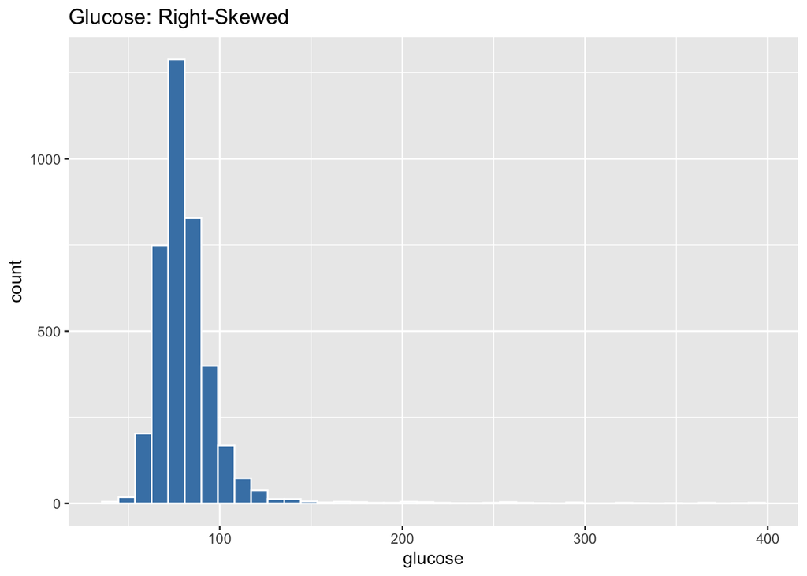

```r
ggplot(framingham, aes(x = glucose)) +
  geom_histogram(bins = 40, fill = "steelblue", color = "white") +
  labs(title = "Glucose: Right-Skewed")
```

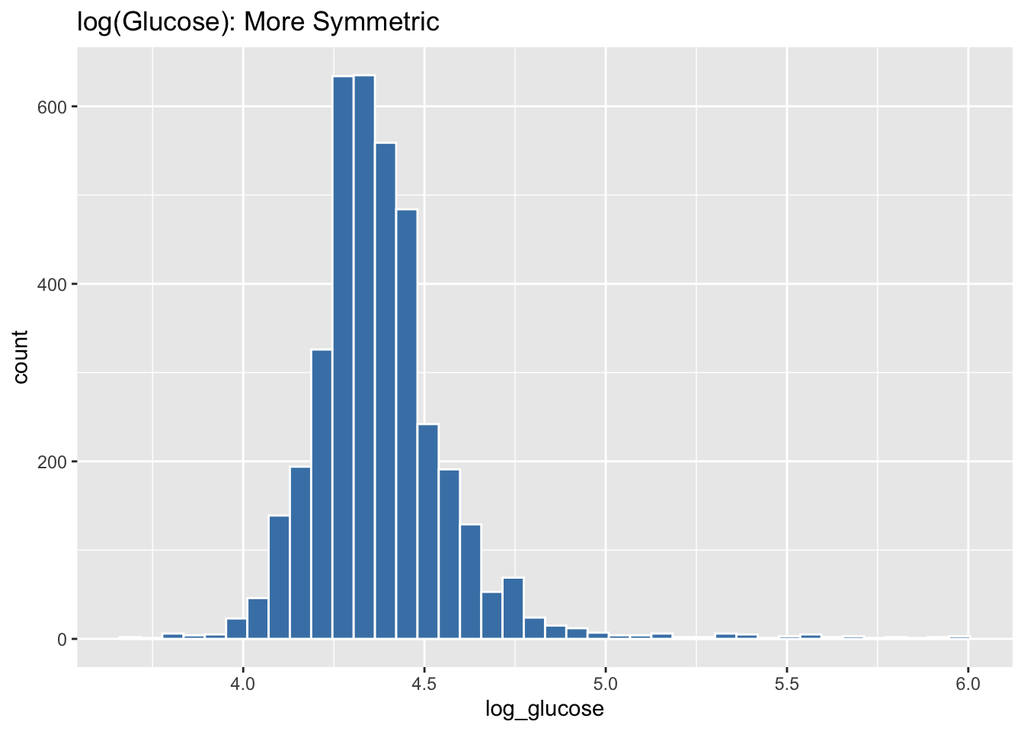

```r
framingham |>
  mutate(log_glucose = log(glucose)) |>
  ggplot(aes(x = log_glucose)) +
  geom_histogram(bins = 40, fill = "steelblue", color = "white") +
  labs(title = "log(Glucose): More Symmetric")
```

## 7.2 Centering and Scaling

Penalized regression, k-NN, and neural networks are sensitive to the *scale* of predictors — a variable measured in the thousands will dominate a variable measured in single digits, independent of its actual importance. Standardizing (subtract the mean, divide by the standard deviation) puts variables on a common scale.

```r
framingham |>
  mutate(sysBP_z = as.numeric(scale(sysBP)))
```

**Important**

Exactly like imputation: compute the mean and SD **on the training set**, and apply those same values to both training and test data. Document 3 walks through a full worked example of this — including what goes wrong when you scale train and test independently — in its “Data Leakage” section.

## 7.3 Encoding Categorical Variables

`lm()` and similar formula-based functions handle factors automatically. Many machine learning functions (`glmnet`, `xgboost`, k-NN implementations) instead require a numeric matrix, so categorical variables need to be converted to **dummy (one-hot) variables** first.

```r
model.matrix(~ education - 1, data = framingham) |> head()
```

```
  educationSome HS educationHS Diploma educationSome College
1                0                   0                     0
2                0                   1                     0
3                1                   0                     0
4                0                   0                     1
5                0                   0                     1
6                0                   1                     0
  educationCollege Degree
1                       1
2                       0
3                       0
4                       0
5                       0
6                       0
```

Each level of `education` becomes its own 0/1 column. The `- 1` removes the intercept column so that all levels are shown; when a model needs a reference level instead (as `lm()` does automatically), drop one column.

Compare this to:

```r
model.matrix(~ education, data = framingham) |> head()
```

```
  (Intercept) educationHS Diploma educationSome College educationCollege Degree
1           1                   0                     0                       1
2           1                   1                     0                       0
3           1                   0                     0                       0
4           1                   0                     1                       0
5           1                   0                     1                       0
6           1                   1                     0                       0
```

# 8 Splitting Data: Training and Test Sets

Every preprocessing decision above — which imputation value to use, which outlier thresholds to apply, how to balance classes, how to center and scale — must be based on the **training data only**, then applied unchanged to the **test data**. That guarantees the test set behaves like genuinely new, unseen data, which is the entire point of having it.

This means the split has to happen early — conceptually, right after you’ve decided what your outcome and candidate predictors are, and before you finalize any of the steps above.

## 8.1 The `rsample` Package

`rsample` (part of the `tidymodels` ecosystem) creates reproducible train/test splits.

```r
set.seed(42)
split <- initial_split(framingham, prop = 0.6, strata = NULL)
train <- training(split)
test  <- testing(split)

dim(train); dim(test)
```

```
[1] 2544   16
```

```
[1] 1696   16
```

- `initial_split()` creates a **split object** that records which rows belong to training vs. test — it does not create two new data frames by itself.
- `prop = 0.6` means 60% of rows go to training, 40% to test. (Common choices range from 0.6–0.8 for training, depending on how much data you have.)
- `training(split)` and `testing(split)` extract the actual data frames.
- Setting `set.seed()` before splitting makes the split reproducible — you and a classmate running the same code will get the same rows in `train`.

**Note**

This is exactly the code you will see reused at the start of document 3, where `dat` replaces `framingham` as the data frame being split. Nothing new happens there — if the code above makes sense, so will that.

## 8.2 The `strata` Argument

`initial_split()` has a `strata` argument, left as `NULL` above. When you supply a variable to `strata`, the split preserves that variable’s distribution across both the training and test sets — the same logic as stratified sampling anywhere else in statistics.

This matters most for **imbalanced outcomes**. Compare an unstratified split…

```r
set.seed(42)
split_plain <- initial_split(framingham, prop = 0.6, strata = NULL)
training(split_plain) |> count(TenYearCHD) |> mutate(pct = n / sum(n) * 100)
```

```
# A tibble: 2 × 3
  TenYearCHD     n   pct
  <fct>      <int> <dbl>
1 No          2166  85.1
2 Yes          378  14.9
```

```r
testing(split_plain)  |> count(TenYearCHD) |> mutate(pct = n / sum(n) * 100)
```

```
# A tibble: 2 × 3
  TenYearCHD     n   pct
  <fct>      <int> <dbl>
1 No          1430  84.3
2 Yes          266  15.7
```

…to a stratified one:

```r
set.seed(42)
split_strat <- initial_split(framingham, prop = 0.6, strata = TenYearCHD)
training(split_strat) |> count(TenYearCHD) |> mutate(pct = n / sum(n) * 100)
```

```
# A tibble: 2 × 3
  TenYearCHD     n   pct
  <fct>      <int> <dbl>
1 No          2157  84.8
2 Yes          386  15.2
```

```r
testing(split_strat)  |> count(TenYearCHD) |> mutate(pct = n / sum(n) * 100)
```

```
# A tibble: 2 × 3
  TenYearCHD     n   pct
  <fct>      <int> <dbl>
1 No          1439  84.8
2 Yes          258  15.2
```

With a rare outcome and a modest sample size, an unstratified split can, by chance, leave the test set with a noticeably different event rate than the training set. Stratifying removes that source of noise.

**Tip**

Default to `strata = <your outcome variable>` for classification problems, especially with class imbalance. For regression, `rsample` also accepts a continuous variable for `strata` (it bins it internally) — document 3 introduces this in its cross-validation section.

## 8.3 Centering and Scaling Split Data

When centering and scaling training and test data, the most natural way to do it may seem like it is:

```r
vars_to_scale <- c("age", "sysBP", "totChol", "BMI", "heartRate", "glucose")

train_scaled <- scale(train[vars_to_scale])
test_scaled  <- scale(test[vars_to_scale])

summary(train_scaled)
```

```
      age               sysBP            totChol              BMI
 Min.   :-1.94559   Min.   :-2.2144   Min.   :-2.91264   Min.   :-2.5485
 1st Qu.:-0.89321   1st Qu.:-0.6873   1st Qu.:-0.69363   1st Qu.:-0.6884
 Median :-0.07469   Median :-0.2157   Median :-0.07723   Median :-0.0729
 Mean   : 0.00000   Mean   : 0.0000   Mean   : 0.00000   Mean   : 0.0000
 3rd Qu.: 0.74383   3rd Qu.: 0.5029   3rd Qu.: 0.58398   3rd Qu.: 0.5623
 Max.   : 2.38086   Max.   : 7.2852   Max.   : 8.13758   Max.   : 4.6476
                                      NA's   :34         NA's   :12
   heartRate           glucose
 Min.   :-2.54223   Min.   :-1.7137
 1st Qu.:-0.66790   1st Qu.:-0.4128
 Median :-0.09745   Median :-0.1689
 Mean   : 0.00000   Mean   : 0.0000
 3rd Qu.: 0.55449   3rd Qu.: 0.1969
 Max.   : 5.44405   Max.   :12.6773
 NA's   :1          NA's   :232
```

```r
summary(test_scaled)
```

```
      age               sysBP            totChol              BMI
 Min.   :-2.03258   Min.   :-2.1541   Min.   :-2.76731   Min.   :-2.2381
 1st Qu.:-0.87060   1st Qu.:-0.7237   1st Qu.:-0.68058   1st Qu.:-0.6426
 Median :-0.05721   Median :-0.1699   Median :-0.05232   Median :-0.1254
 Mean   : 0.00000   Mean   : 0.0000   Mean   : 0.00000   Mean   : 0.0000
 3rd Qu.: 0.75618   3rd Qu.: 0.5222   3rd Qu.: 0.57595   3rd Qu.: 0.5351
 Max.   : 2.38296   Max.   : 5.1827   Max.   :10.31402   Max.   : 7.5533
                                      NA's   :16         NA's   :7
   heartRate           glucose
 Min.   :-2.69917   Min.   :-1.8153
 1st Qu.:-0.63636   1st Qu.:-0.4650
 Median :-0.03471   Median :-0.1601
 Mean   : 0.00000   Mean   : 0.0000
 3rd Qu.: 0.56694   3rd Qu.: 0.1992
 Max.   : 4.00494   Max.   :13.2558
                    NA's   :156
```

**DO NOT DO THIS!!**

Centering and scaling your data based on the training data is important. Why? Consider a situation where you only had one covariate (say `age`) and the test data only had one subject. If you centered the test data individually, the mean would be the subjects value. So, they would have `age_z=0` no matter what. **Always center and scale based on the training data.**

Here’s how we can do this:

```r
## Center and scale numeric predictors: fit on train, apply to test

vars_to_scale <- c("age", "sysBP", "totChol", "BMI", "heartRate", "glucose")

scaled_train <- scale(train[vars_to_scale]) # computes mean/SD from train

str(scaled_train)
```

```
 num [1:2544, 1:6] 0.276 -0.893 0.51 0.276 0.978 ...
 - attr(*, "dimnames")=List of 2
  ..$ : NULL
  ..$ : chr [1:6] "age" "sysBP" "totChol" "BMI" ...
 - attr(*, "scaled:center")= Named num [1:6] 49.6 132.8 236.9 25.9 76.2 ...
  ..- attr(*, "names")= chr [1:6] "age" "sysBP" "totChol" "BMI" ...
 - attr(*, "scaled:scale")= Named num [1:6] 8.55 22.26 44.61 4.05 12.27 ...
  ..- attr(*, "names")= chr [1:6] "age" "sysBP" "totChol" "BMI" ...
```

```r
# Extract the mean and sd from the scaled_train
mu <- attr(scaled_train, "scaled:center")
sdv <- attr(scaled_train, "scaled:scale")

train_scaled <- train
test_scaled  <- test
train_scaled[vars_to_scale] <- scaled_train
test_scaled[vars_to_scale]  <- scale(test[vars_to_scale], center = mu, scale = sdv)

summary(train_scaled[vars_to_scale])
```

```
      age               sysBP            totChol              BMI
 Min.   :-1.94559   Min.   :-2.2144   Min.   :-2.91264   Min.   :-2.5485
 1st Qu.:-0.89321   1st Qu.:-0.6873   1st Qu.:-0.69363   1st Qu.:-0.6884
 Median :-0.07469   Median :-0.2157   Median :-0.07723   Median :-0.0729
 Mean   : 0.00000   Mean   : 0.0000   Mean   : 0.00000   Mean   : 0.0000
 3rd Qu.: 0.74383   3rd Qu.: 0.5029   3rd Qu.: 0.58398   3rd Qu.: 0.5623
 Max.   : 2.38086   Max.   : 7.2852   Max.   : 8.13758   Max.   : 4.6476
                                      NA's   :34         NA's   :12
   heartRate           glucose
 Min.   :-2.54223   Min.   :-1.7137
 1st Qu.:-0.66790   1st Qu.:-0.4128
 Median :-0.09745   Median :-0.1689
 Mean   : 0.00000   Mean   : 0.0000
 3rd Qu.: 0.55449   3rd Qu.: 0.1969
 Max.   : 5.44405   Max.   :12.6773
 NA's   :1          NA's   :232
```

```r
summary(test_scaled[vars_to_scale])
```

```
      age               sysBP             totChol              BMI
 Min.   :-2.06252   Min.   :-2.14705   Min.   :-2.77815   Min.   :-2.31660
 1st Qu.:-0.89321   1st Qu.:-0.75468   1st Qu.:-0.69363   1st Qu.:-0.69581
 Median :-0.07469   Median :-0.21570   Median :-0.06603   Median :-0.17035
 Mean   :-0.01712   Mean   :-0.05027   Mean   :-0.01377   Mean   :-0.04297
 3rd Qu.: 0.74383   3rd Qu.: 0.45803   3rd Qu.: 0.56157   3rd Qu.: 0.50067
 Max.   : 2.38086   Max.   : 4.99448   Max.   :10.28935   Max.   : 7.63019
                                       NA's   :16         NA's   :7
   heartRate           glucose
 Min.   :-2.62372   Min.   :-1.71372
 1st Qu.:-0.66790   1st Qu.:-0.45349
 Median :-0.09745   Median :-0.16892
 Mean   :-0.06454   Mean   :-0.01948
 3rd Qu.: 0.47300   3rd Qu.: 0.16646
 Max.   : 3.73270   Max.   :12.35205
                    NA's   :156
```

The test data does not exactly have mean zero and that is okay. It shouldn’t. The test data is supposed to represent what we could see in practice, and it will not exactly match the training data.

## 8.4 What Comes Next

Once `train` and `test` exist, every step from this document gets applied in order: diagnose and handle missingness, check outliers, address imbalance, engineer and encode features, and center/scale — fit on `train`, applied to both. Document 3 extends this same idea one level further, splitting `train` itself repeatedly via cross-validation (`vfold_cv()`) to tune models honestly without ever touching `test` until the very end.

# 9 Preprocessing Checklist

1. Split into training and test sets (`strata` on the outcome if imbalanced).
2. Diagnose missingness in the training set; choose complete-case analysis or an imputation strategy and compute any imputation values from `train` only.
3. Check for outliers; decide fix, cap, transform, or leave, based on domain knowledge, not on what improves test performance.
4. Check for class imbalance in the outcome; decide whether to up/downsample `train` (never `test`).
5. Engineer features: transformations, interactions, encoding categorical variables as needed for the model you plan to use.
6. Center/scale numeric predictors if using a scale-sensitive model, fit on `train`, applied to `test`.
7. Apply every choice from steps 2–6 to `test` using values learned from `train` — never recompute them on `test`.

# 10 Summary

- Missing data, outliers, and class imbalance are the norm in public health data, not the exception — diagnose before deciding how to handle them.
- Every preprocessing choice that involves estimating something from data (an imputation value, an outlier threshold, a centering/scaling parameter) must be estimated on the training set only.
- `rsample::initial_split()`, `training()`, and `testing()` create the train/test split that makes this possible, and `strata` protects you from an unlucky split when the outcome is imbalanced.
- This train/test split is the first line of code in document 3 — everything from here forward assumes you know what it does.